# Assignment 7

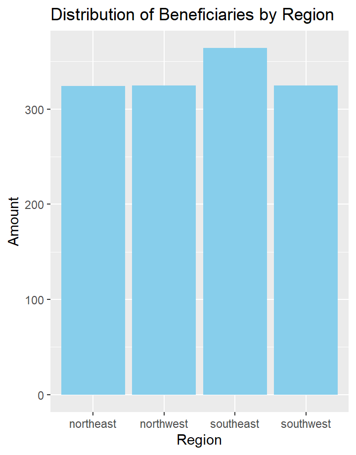

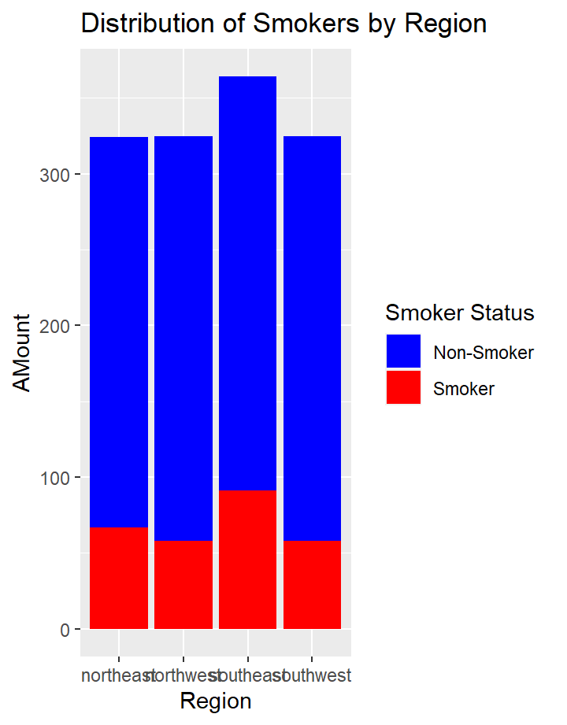

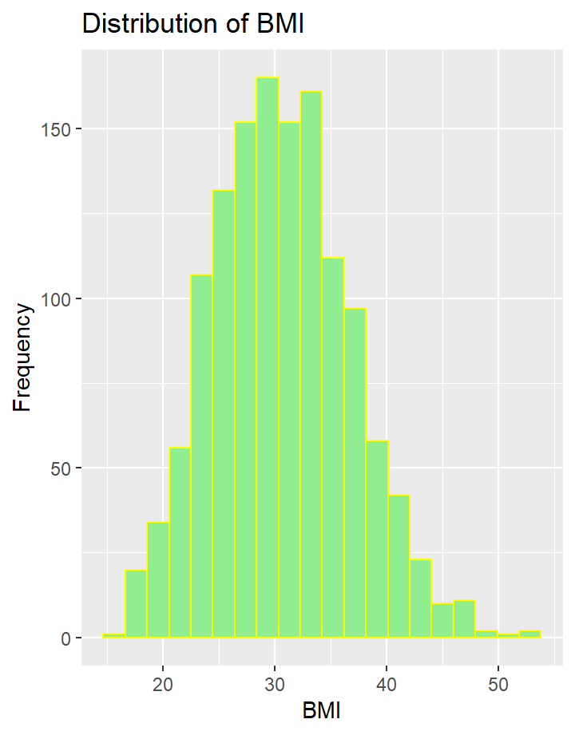

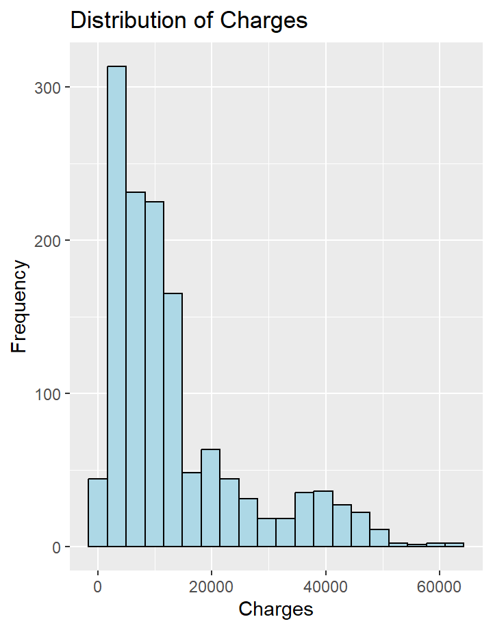

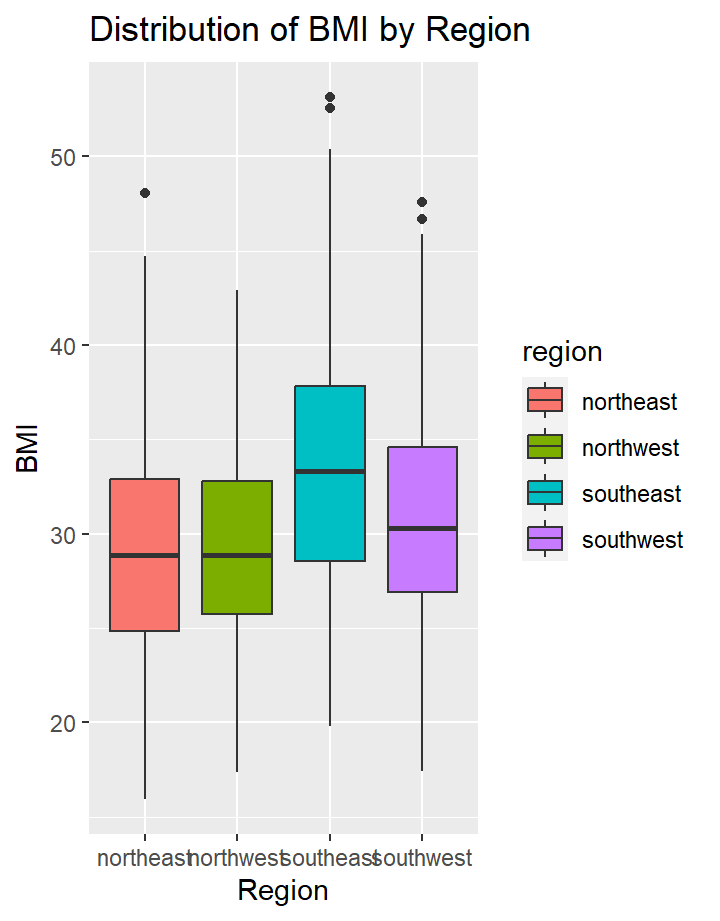

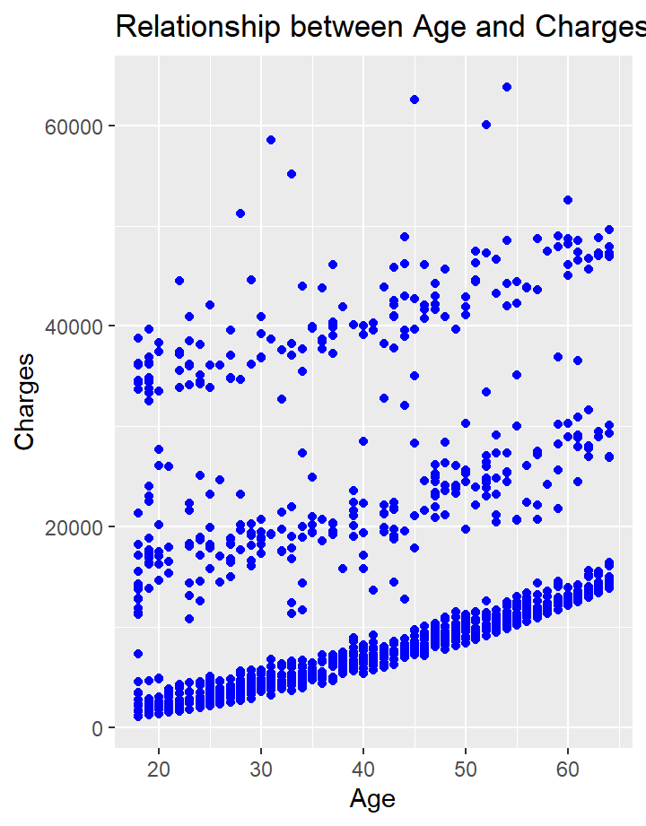

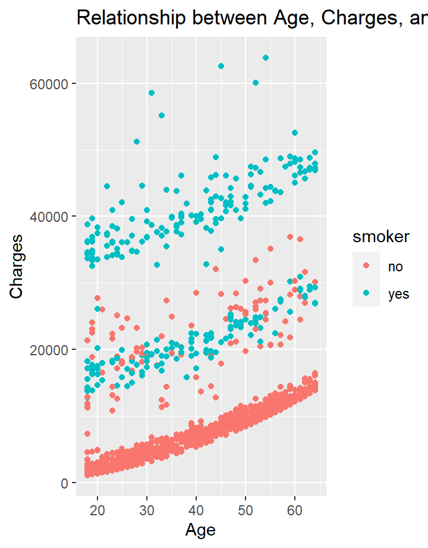

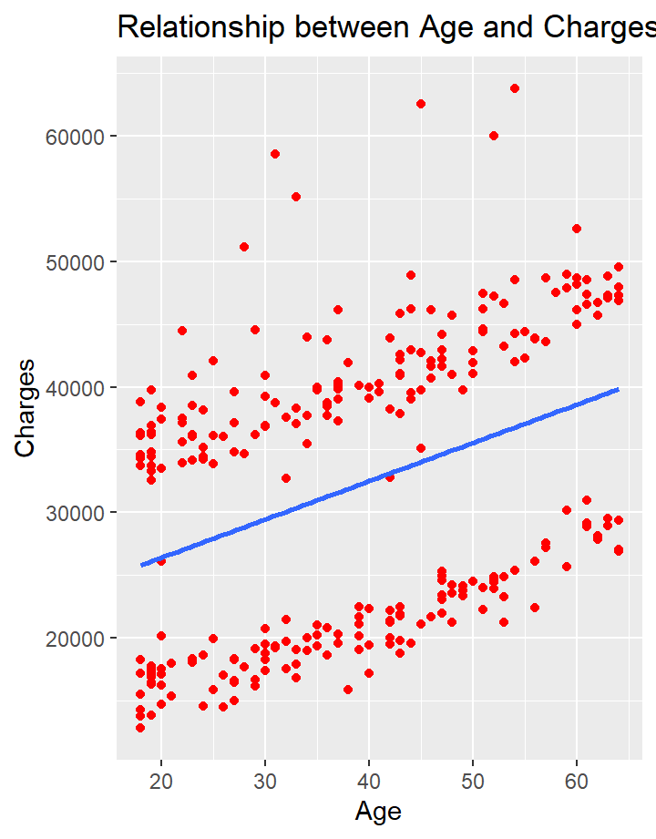

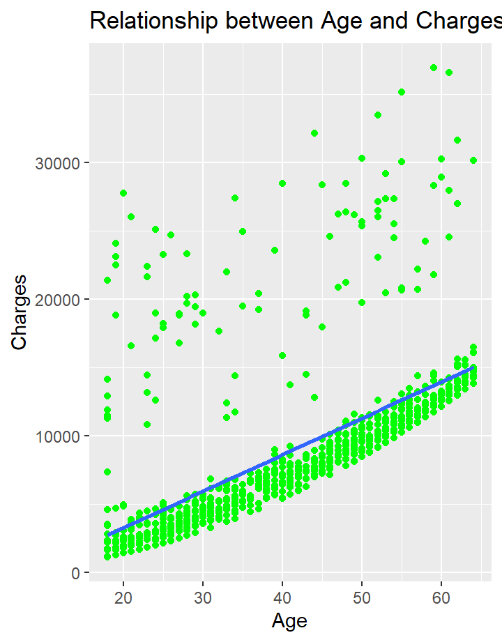

[figure not shown]

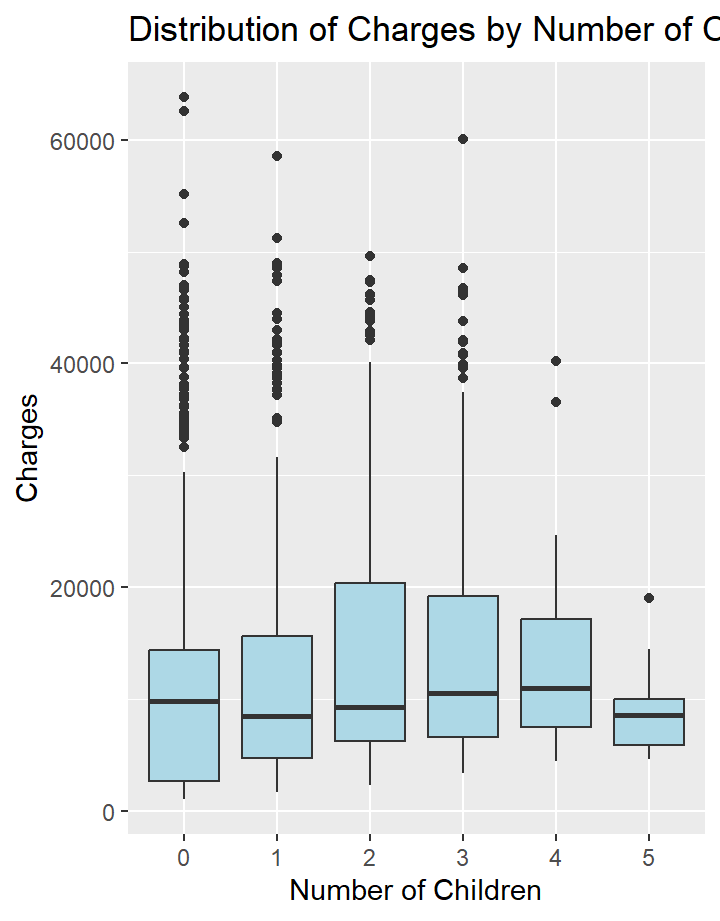

# Overall Analysis

### Glimpse of Insurance

```
Rows: 1,338
Columns: 7
$ age      <dbl> 19, 18, 28, 33, 32, 31, 46, 37, 37, 60, 25, 62, 23, 56, 27, 1…
$ sex      <chr> "female", "male", "male", "male", "male", "female", "female",…
$ bmi      <dbl> 27.900, 33.770, 33.000, 22.705, 28.880, 25.740, 33.440, 27.74…
$ children <dbl> 0, 1, 3, 0, 0, 0, 1, 3, 2, 0, 0, 0, 0, 0, 0, 1, 1, 0, 0, 0, 0…
$ smoker   <chr> "yes", "no", "no", "no", "no", "no", "no", "no", "no", "no", …
$ region   <chr> "southwest", "southeast", "southeast", "northwest", "northwes…
$ charges  <dbl> 16884.924, 1725.552, 4449.462, 21984.471, 3866.855, 3756.622,…
```

Brief Analysis

In assignment 6, we were given a csv file named insurance. Insurance has 1338 observations and 7 variables. The 7 variables where: age, sex, bmi, children, smoker, region, and charges. Then we were asked to compare the variables to eachother and show this comparison through different graphs. The major point of all of the variables was how they impacted the relationship to charges. Basically, how does each variable compare to charges.

# Question 1 and Question 2

### Read the data file insurance.csv using the read_csv() function in tidyverse.

```
Rows: 1,338
Columns: 7
$ age      <dbl> 19, 18, 28, 33, 32, 31, 46, 37, 37, 60, 25, 62, 23, 56, 27, 1…
$ sex      <chr> "female", "male", "male", "male", "male", "female", "female",…
$ bmi      <dbl> 27.900, 33.770, 33.000, 22.705, 28.880, 25.740, 33.440, 27.74…
$ children <dbl> 0, 1, 3, 0, 0, 0, 1, 3, 2, 0, 0, 0, 0, 0, 0, 1, 1, 0, 0, 0, 0…
$ smoker   <chr> "yes", "no", "no", "no", "no", "no", "no", "no", "no", "no", …
$ region   <chr> "southwest", "southeast", "southeast", "northwest", "northwes…
$ charges  <dbl> 16884.924, 1725.552, 4449.462, 21984.471, 3866.855, 3756.622,…
```

### Get a glimpse of the data

```
Rows: 1,338
Columns: 7
$ age      <dbl> 19, 18, 28, 33, 32, 31, 46, 37, 37, 60, 25, 62, 23, 56, 27, 1…
$ sex      <chr> "female", "male", "male", "male", "male", "female", "female",…
$ bmi      <dbl> 27.900, 33.770, 33.000, 22.705, 28.880, 25.740, 33.440, 27.74…
$ children <dbl> 0, 1, 3, 0, 0, 0, 1, 3, 2, 0, 0, 0, 0, 0, 0, 1, 1, 0, 0, 0, 0…
$ smoker   <chr> "yes", "no", "no", "no", "no", "no", "no", "no", "no", "no", …
$ region   <chr> "southwest", "southeast", "southeast", "northwest", "northwes…
$ charges  <dbl> 16884.924, 1725.552, 4449.462, 21984.471, 3866.855, 3756.622,…
```

### Number of observations and variables in the data.

Number of observations

```
[1] 1338
```

Number of variables

```
[1] 7
```

# Question 3

### Create a bar plot of region.

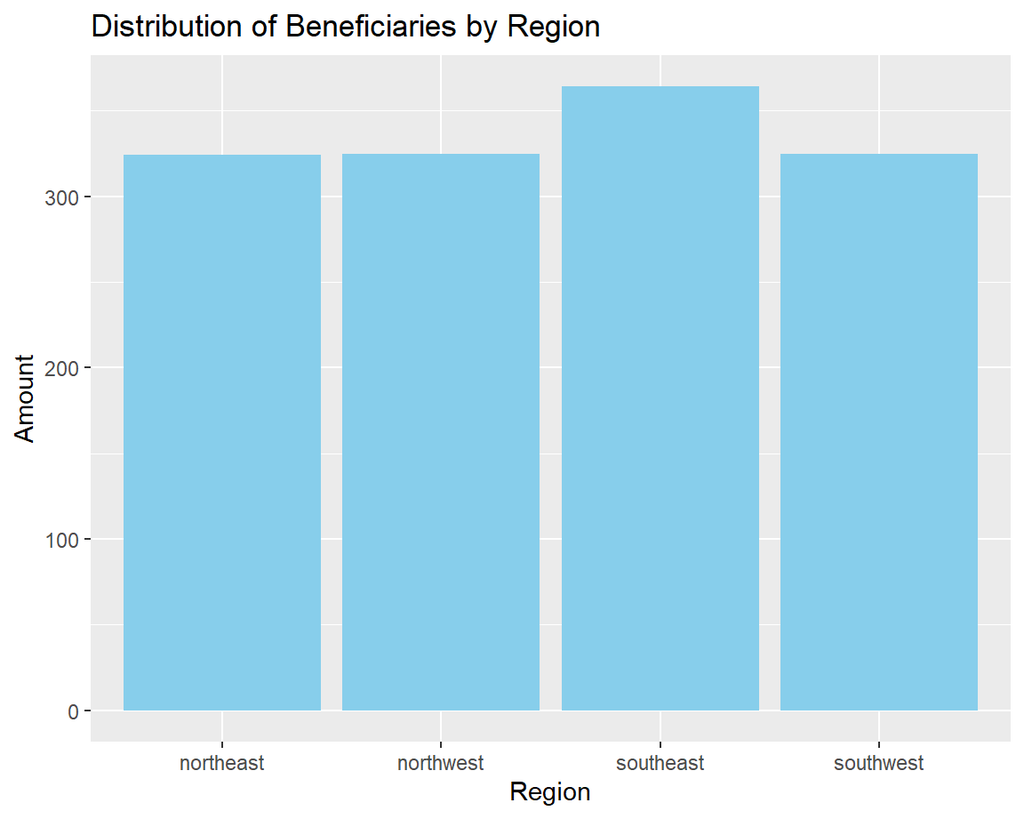

### Summarize your findings

The amount is relatively evenly spread out between the four regions. However Southeast has the most and northeast has the least. All of the regions hvae over 300 beneficiaries.

# Question 4 and Question 5

### Question 4

Create a stack bar plot such that region is on the x axis and each bar shows the distribution of smoker in that region.

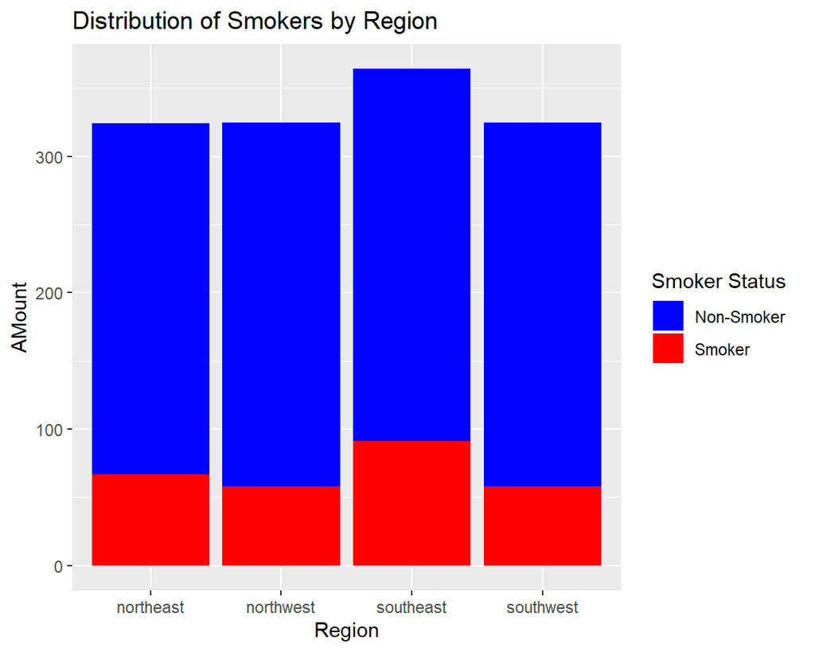

### Question 5 Histogram of bmi

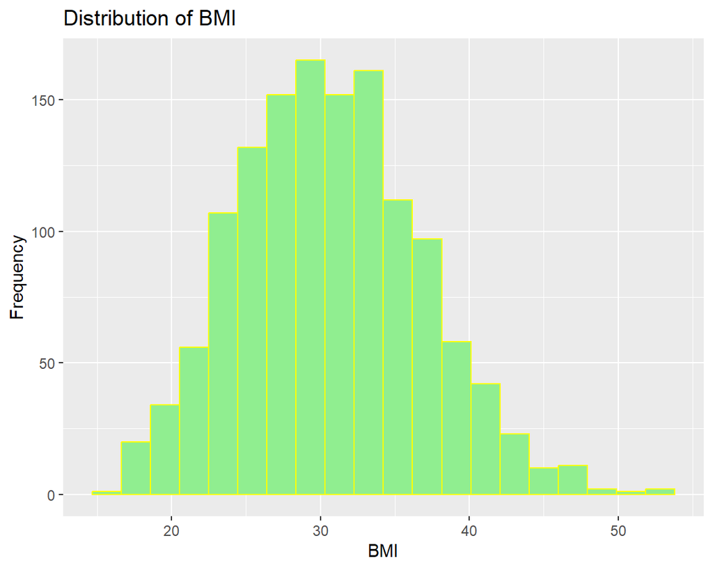

### Discuss the distribution of the histogram

The middle of the histogram is approximately 30. The right side of the histogram is smoother, while the left side of the curve is steeper.

# Question 6

### Create a histogram of charges

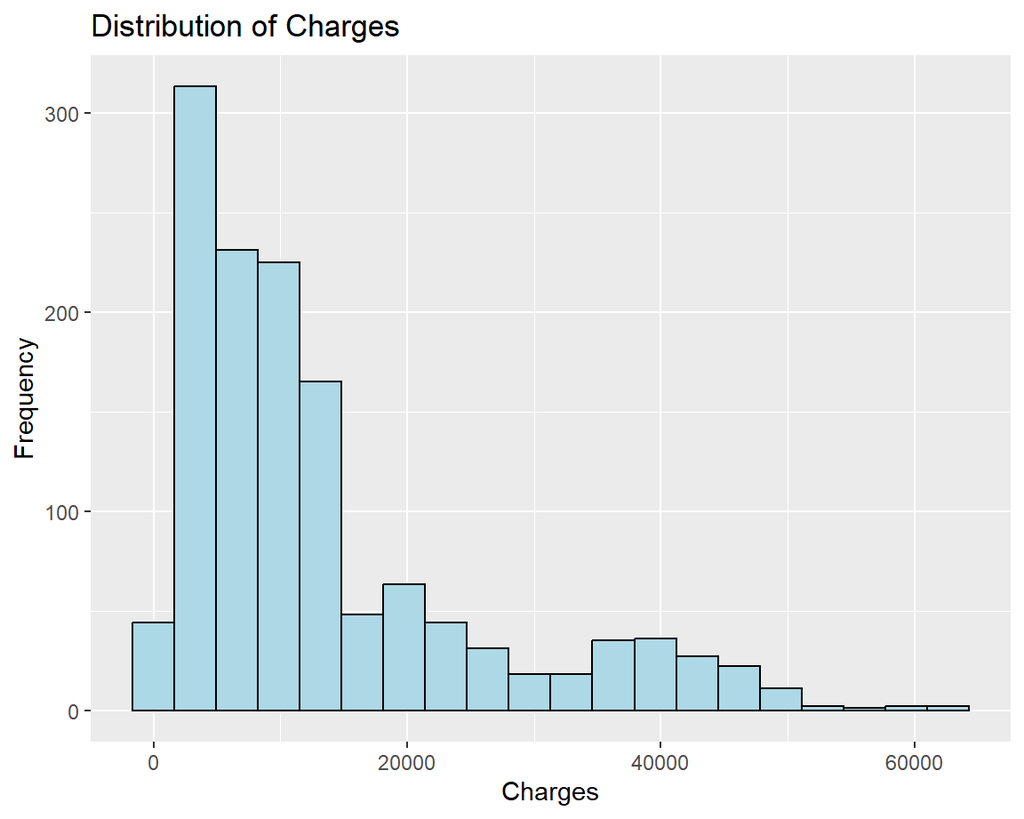

### Discuss the distribution of the histogram

The histogram has a steep left side and a smoother right side. the highest point is the second bin in the graph. the right side smooths out and then keeps a semi consistent tail providing a rightward skew.

# Question 7

### Boxplot that shows the distribution of bmi based on the region

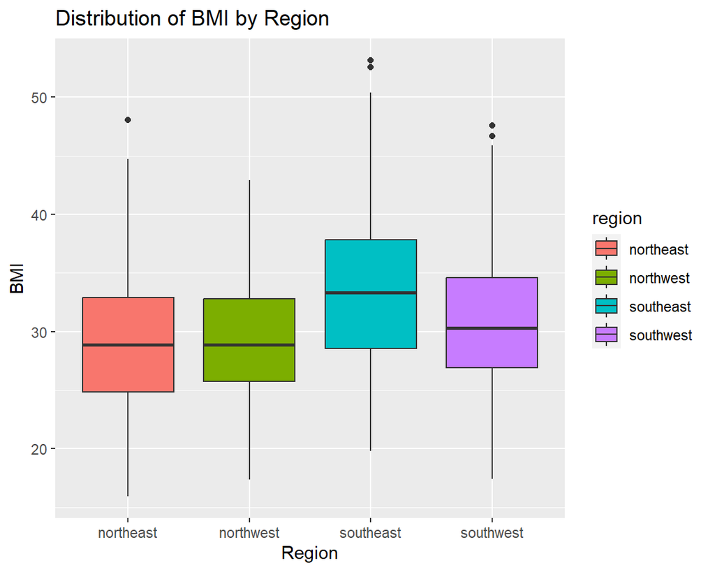

### Discuss what you find based on the boxplot

The north east and north west distributions are nearly identical. The south west is just above those two with its median and quarters. The south east is above all of them, with the highest median, QR1, QR3, maximum, and minimum.

# Question 8

### Scatterplot between age and charges

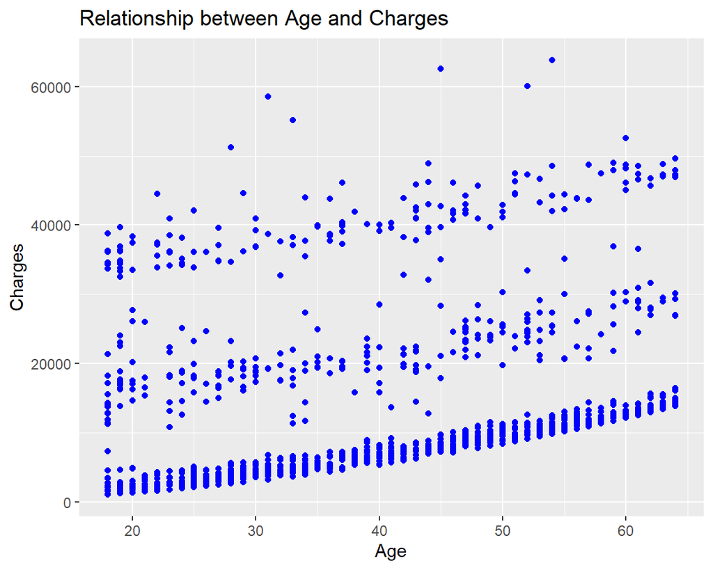

### Comments on the scatterplot

Overall there is a positive relationship between age and charges. The data can be mostly represented by three different linear lines each with a different y intercept.

# Question 9 and Question 10

### Scatterplot of age and charges with smoker as a categorical variable

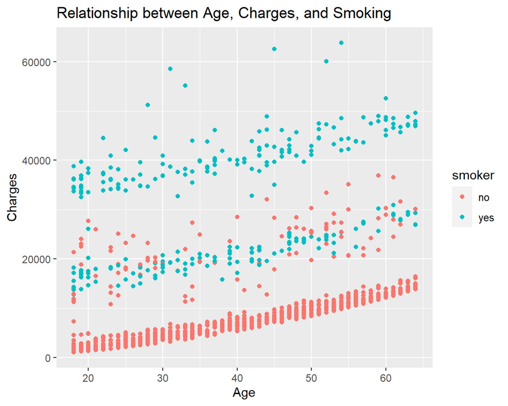

### Comments on the Scatterplot

There is a positive relationship between age and charges. However, nonsmokers generally have lower charges.

### Question 10

Create two data frames by subsetting insurance data as smoker and nonsmoker.

```r
smoker <- insurance[insurance$smoker == "yes", ]
nonsmoker <- insurance[insurance$smoker == "no", ]
```

# Question 11

### Scatterplot of age vs charges for smokers

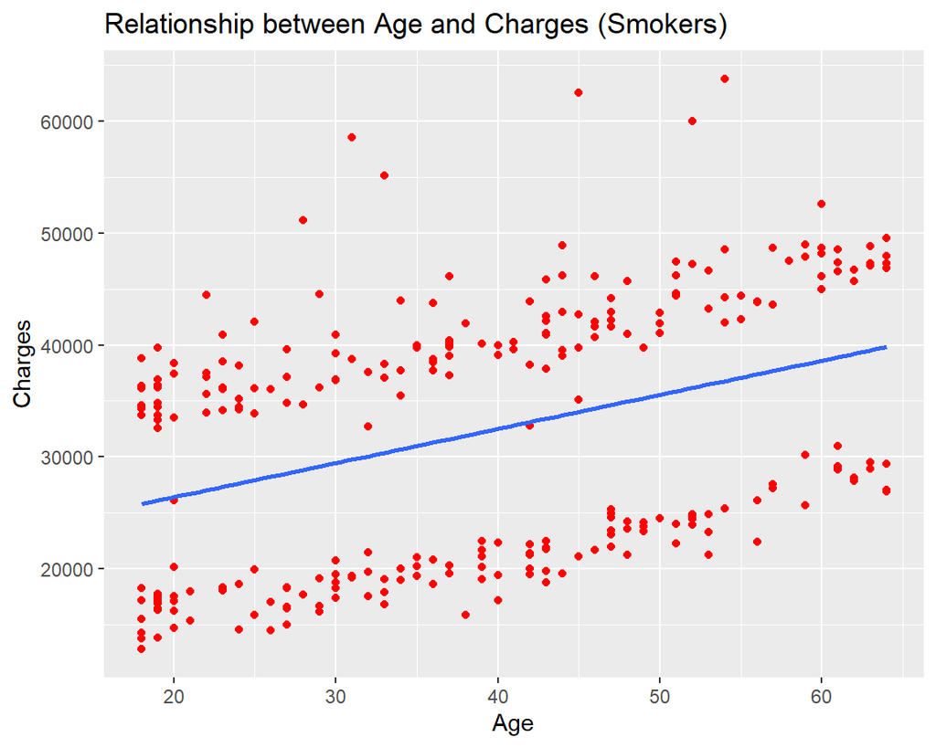

### Comments on the plot and smooth line summary

The smooth line is in the middle of the data points, but few of the data points are close to the line. most are above or below by at least $5000. The line is an accurate way to describe the data, but the data is also nowhere near the line. So, I do not think the line is a good way to summarize the data.

# Question 12

### Scatterplot of age vs charges for non-smokers

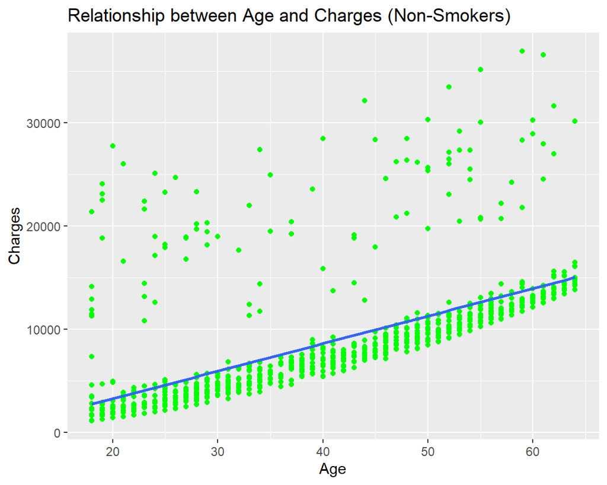

### Comments on the plot and smooth line summary

The line is much closer to the data points. The data below the line is nearly on it, but data above is farther away and more random. I think the line is a good representation. This is what I said in assignment six. But when going over this, I do not like the line as a summary.

# Question 13 and 14

### What you might do next if you want to model charges using other variables in this data

Create models using other variables including BMI, number of children, and region. This builds a comprehensive model for predicting the medical charges.

### Pie chart of children

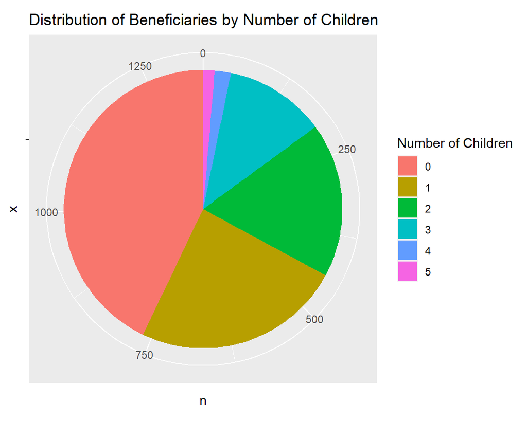

### Summarize your findings

Most beneficiaries have 0 or 1 child. Next most is 2, then 3, and finally 5 children is represented the least by the beneficiaries. ALmost half of the beneficiaries have no children.

# Question 15

### Boxplot that shows the distribution of charges based on the number of children

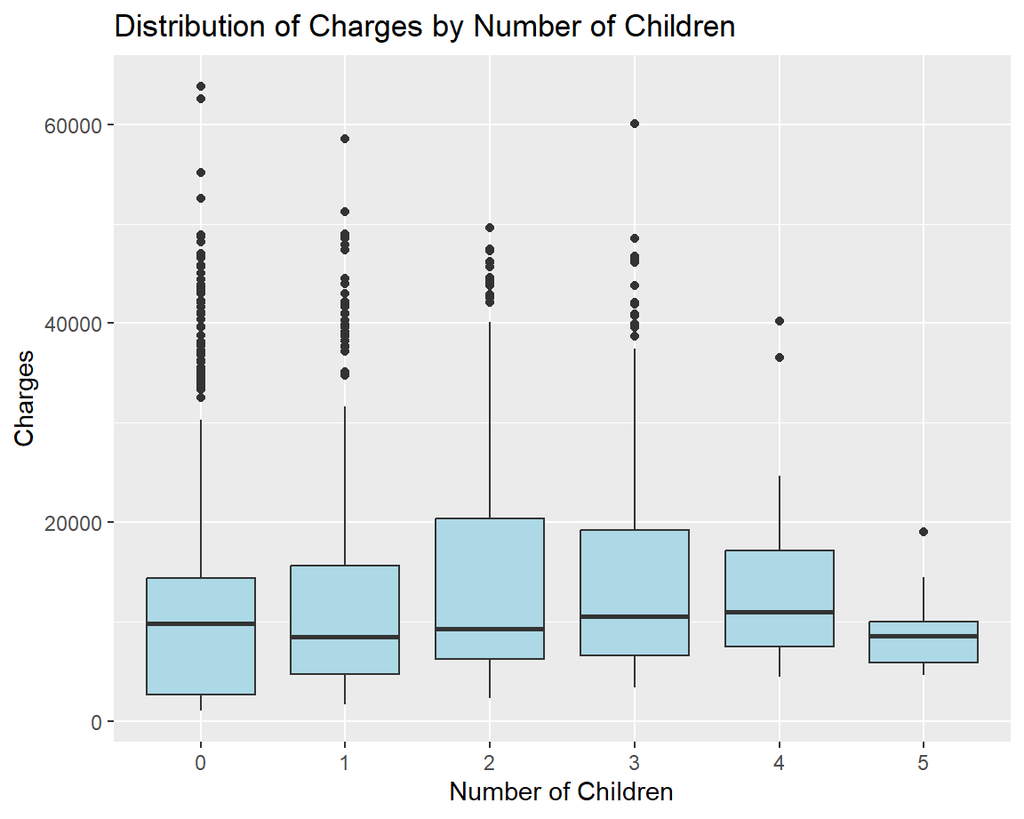